# Regression Models Course Project

Yolanda Xu

February 21, 2015

## Executive Summary

This Yolanda Xu, who works for Motor Trend, a magazine about the automobile industry. Looking at a data set of a collection of cars, we are interested in exploring the relationship between a set of variables and miles per gallon (MPG) (outcome). We are particularly interested in the following two questions:

1. “Is an automatic or manual transmission better for MPG”
2. “Quantify the MPG difference between automatic and manual transmissions”

Thus, these two questions are my focuses in this project.

```r
data(mtcars)
head(mtcars)
```

```
##                    mpg cyl disp  hp drat    wt  qsec vs am gear carb
## Mazda RX4         21.0   6  160 110 3.90 2.620 16.46  0  1    4    4
## Mazda RX4 Wag     21.0   6  160 110 3.90 2.875 17.02  0  1    4    4
## Datsun 710        22.8   4  108  93 3.85 2.320 18.61  1  1    4    1
## Hornet 4 Drive    21.4   6  258 110 3.08 3.215 19.44  1  0    3    1
## Hornet Sportabout 18.7   8  360 175 3.15 3.440 17.02  0  0    3    2
## Valiant           18.1   6  225 105 2.76 3.460 20.22  1  0    3    1
```

As from the summary, variables “cyl”, “vs”, “am”, “gear” and “carb” are categorical variables, so I will creat factors for these during the regression.

```r
mtcars$cyl<-factor(mtcars$cyl)
mtcars$vs<-factor(mtcars$vs, levels=c(0, 1), labels=c("s", "v"))
mtcars$am<-factor(mtcars$am, levels=c(0, 1), labels =c("automatic", "manual"))
mtcars$gear<-factor(mtcars$gear)
mtcars$carb<-factor(mtcars$carb)
```

## Exploratory Analysis

From Figure 2.violin plot, motors with “am” as “manual” have higher mean than those with “am” as “automatic”.

## Regression Models

```r
fit1<-lm(mpg~., data=mtcars)
fit2<-lm(mpg~am, data=mtcars)
fit3<-lm(mpg~am+wt, data=mtcars)
fit4<-lm(mpg~am*wt, data=mtcars)
summary(fit4)$coefficients
```

```
##              Estimate Std. Error   t value     Pr(>|t|)
## (Intercept) 31.416055  3.0201093 10.402291 4.001043e-11
## ammanual    14.878423  4.2640422  3.489277 1.621034e-03
## wt          -3.785908  0.7856478 -4.818836 4.551182e-05
## ammanual:wt -5.298360  1.4446993 -3.667449 1.017148e-03
```

fit1 includes all the variables. With 95% confidence, none of the variables satisfies t-test.

fit2 is a simple fit of the problem. am(mannual) has coefficient 7.245, which means the manual transmission motors is 7.245 miles higher than the automatic transimission motors in “mpg”. It shows significant difference with p=0.000285.With 95% confidence, we can estimate that the actual difference between manual and automatic transmission motors is within range (3.64, 10.85).

fit3 to fit4 add more varible of “wt”, which are considered to be correlated to both “mpg” and “am”. I include the interaction term in the model fit4, and this one shows the highest R-squared value of 0.833. The high highest R-squared value indicates taht the model explains much more variance than all the others. Also, actually including more variables like “cyl”, “disp” and “drat” might give a better R-squared value of 0.90, but the limited increase in explained variance make the model much more complicated to interpret. It might be a phenomenon of vairance inflation, so I drop those models here.

We can see that there is a difference between automatic and manual transimission:

## Conclusion

To conclude, though we build a satisfactory regression model here, we leave out many factors like “cyl”, “disp” and “drat”, which might increase the explained variance and build a better model.

## Apendix

#### Figure 2.

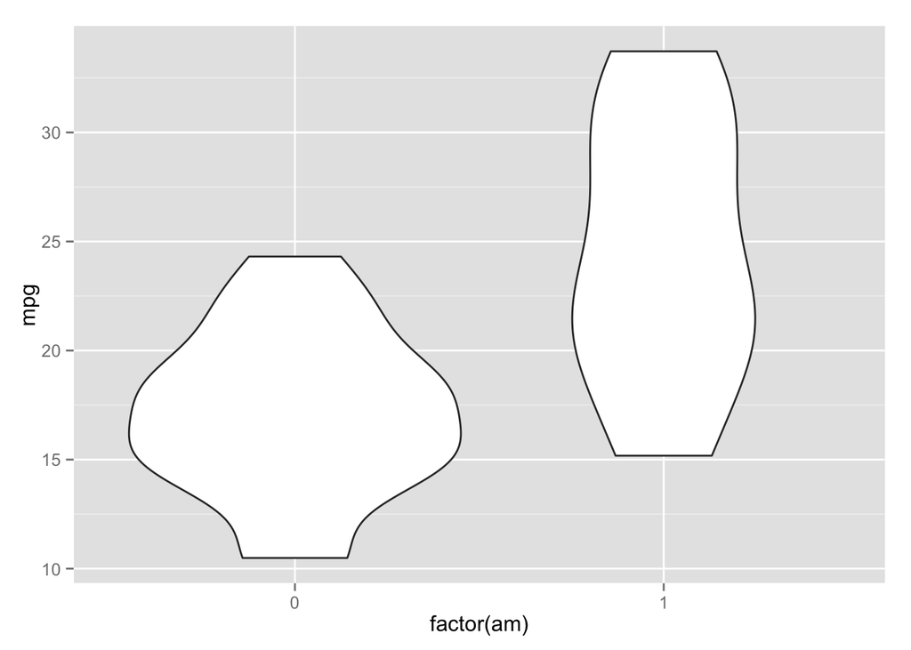

#### Figure 3.

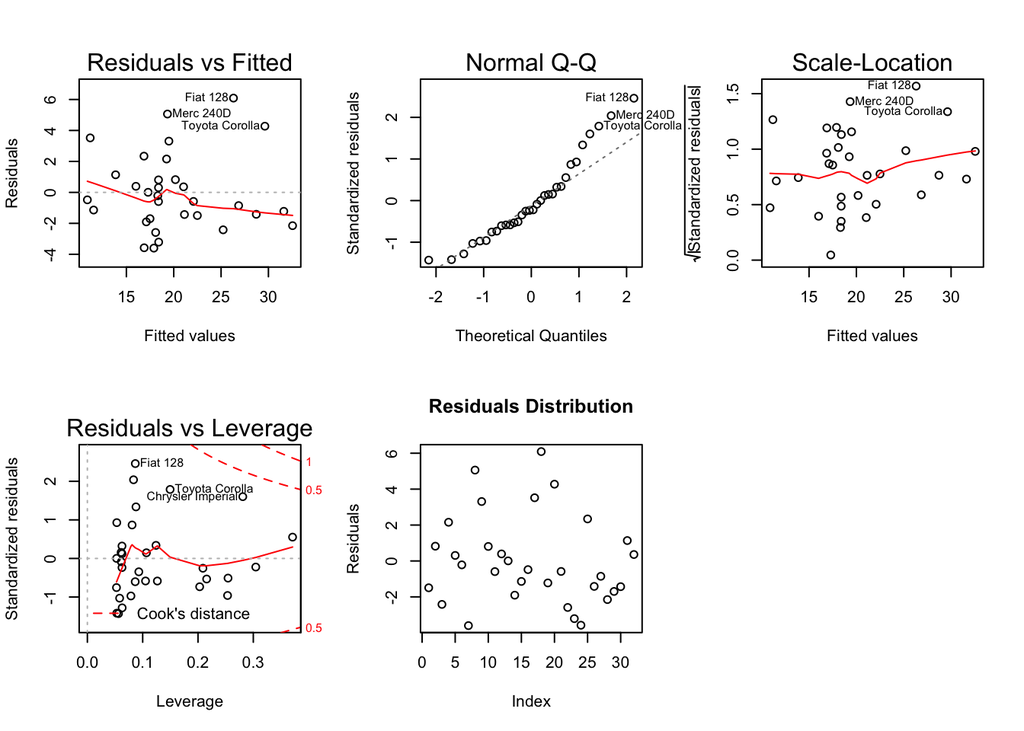